# EXPLORING PROSPER LOAN DATASET

### `Observation`

> - The pattern here show that the borrowers take loan more for Debt Consolidation, Baby & Adoption, Business and Wedding loans. Students apply for the least loan on average. One could deduce that the borrowers seem to need the loan more for simply personal expenditures than for investments. Sadly, they basically borrow to consume.

### Question D. Consider the relationship ProsperRating and IncomeRange vs Home onwership

### `Visualization`

> To make use of a clustered bar chart, we will have to define two functions - *the compute_proportions()* which will compute the proportion of the y-axis within the x-axis variable, wile the second function, *plot_proportions()* will plot a column bar chart that will be based on the computed proportions.

```python
# defining the two proportions
def compute_proportions(df, group_col, proportion_col):
    """
        Computes the proportions of proportion_col within group_col
        Params:
            :df (dataframe): dataframe of interest
            :group_col (string): name of grouping column
            :proportion_col (string): name of column to compute proportions for
        Output:
            returns a dataframe with relative frequencies of proportion_col within group_col
    """
    # First group dataframe by group_col and proportion_col
    result = df.groupby([group_col, proportion_col]).agg({proportion_col: 'size'})

    # Compute the proportions of proportion_col within group_col
    result = result.groupby(level=0).apply(lambda x: 100 * x / float(x.sum()))

    # Rename proportion results and reset dataframe index
    result.rename(columns={proportion_col: 'percent_of_total'}, inplace=True)
    result = result.reset_index()
    return result

def plot_proportions(df, group_col, proportion_col, cmap):
    """ Creates a clustered bar chart  of prop_col and group_col"""
    # Call the compute proportion function
    table = compute_proportions(df, group_col, proportion_col)
    # Create Column bar chart
    sns.barplot(data=table, x= group_col, y= 'percent_of_total', hue=proportion_col, palette=cmap, color=colors[4])
    plt.legend(bbox_to_anchor=(1,1), loc="upper left", title=proportion_col)
```

> - **Is there any Relationship between Propser Rating and Income Range?**

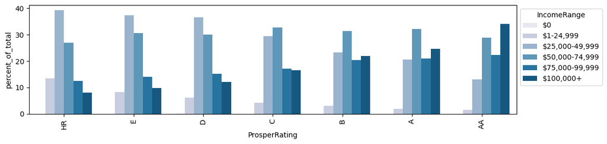

```python
plt.figure(figsize=(12,8))

# ProsperRating and IncomeRange
plt.subplot(3,1,1)
plot_proportions(clean_df, 'ProsperRating', 'IncomeRange','PuBu')

plt.xticks(rotation=90)
plt.tight_layout();
```

> - **Visualize the Relationship between Propser Rating and Home Owership**

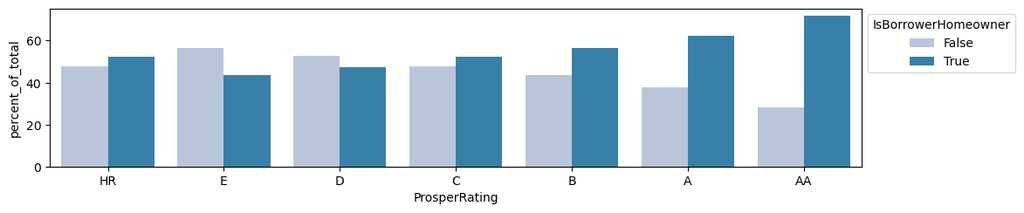

```python
plt.figure(figsize=(12,8))
# Prosper Rating and IsBorrowerHomeowner
plt.subplot(3,1,2)
plot_proportions(clean_df, 'ProsperRating', 'IsBorrowerHomeowner', 'PuBu')
```

## 7.1 Limitation

> As a limitation to our analysis, we much as we exmined the correlations between our main features of interest, we cannnot firmly say that one feature influenced other with certainty. Thus, this study was only an observatory from the dataset at hand.

## 7.2 Saving our work

```python
# Save our finished cleaned data locally
clean_df.to_csv('Prosper_Project.csv')
```